# Visualisasi data Numerik

## DENSITY PLOT SEDERHANA

Pada dasarnya density tidak bisa melihat outlier, untuk itu identifikasi outlier dapat menggunakan histogram dan Untuk membuat density plot menggunakan ggplot2 kita cukup menggunakan function geom_density()

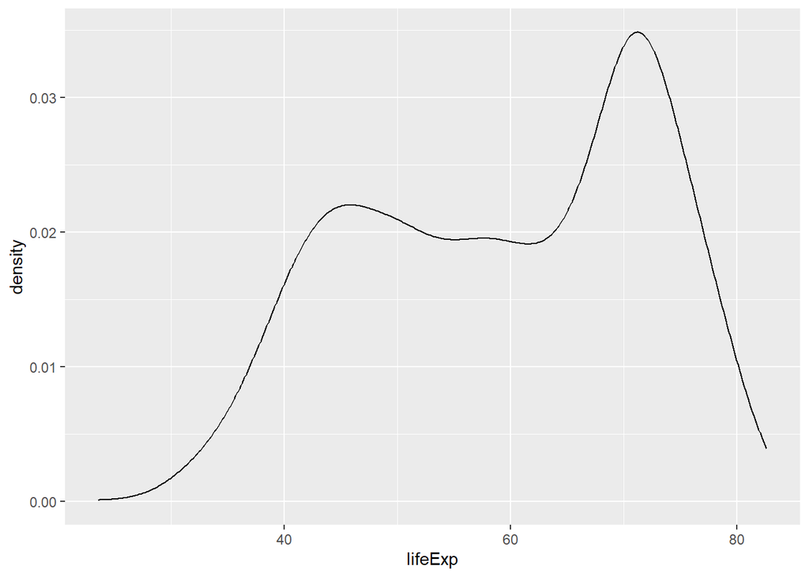

```r
ggplot(data = gapminder, mapping = aes(x = lifeExp)) +
  geom_density()
```

Untuk mengatur warna, transaparansi, format penulisan nilai pada sumbu x dan y, dan labeling sumbu x sama seperti pembuatan Histogram. Hasilnya sebagai berikut.

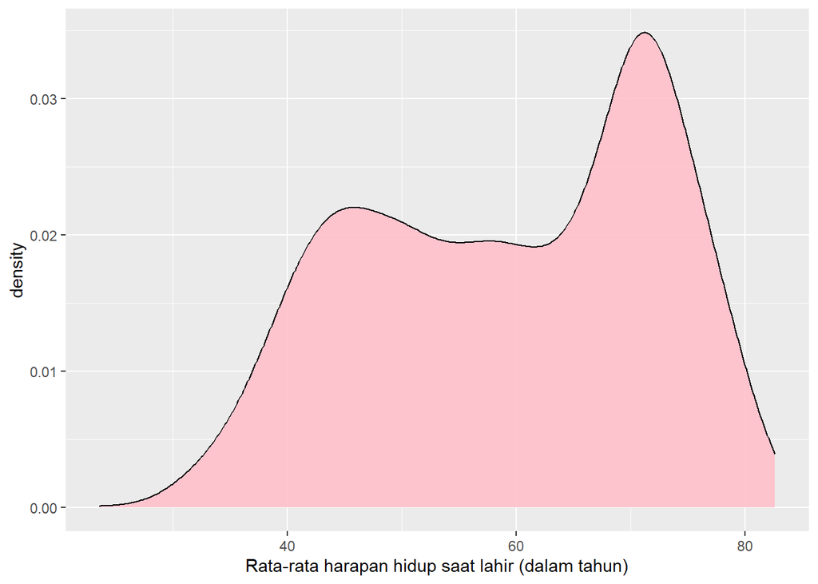

```r
ggplot(data = gapminder, mapping = aes(x = lifeExp)) +
  geom_density(fill = "pink", alpha = 0.9) +
  scale_x_continuous(labels = comma) +
  scale_y_continuous(labels = comma) +
  labs(x = "Rata-rata harapan hidup saat lahir (dalam tahun)")
```

Kita dapat membandingkan sebaran menggunakan **density plot** berdasarkan kategori. Misal akan dilihat sebaran rata-rata hidup saat lahir berdasarkan kategori continent. Hasilnya sebagai berikut.

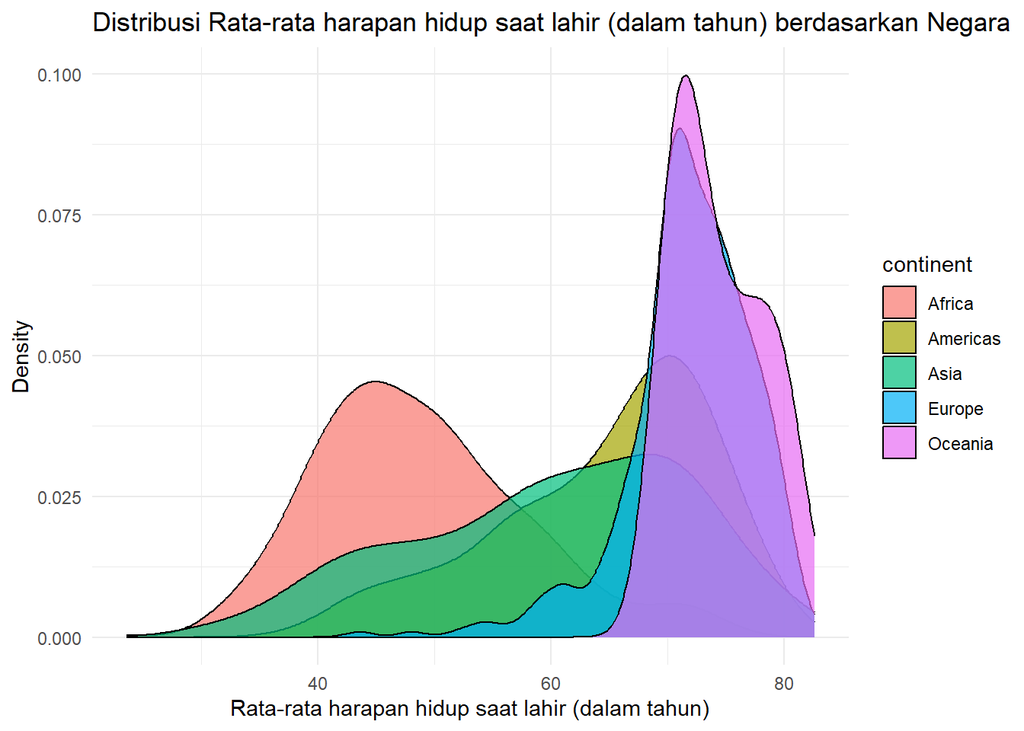

```r
library(ggplot2)
library(scales)

ggplot(data = gapminder, mapping = aes(x = lifeExp, fill = continent)) +
  geom_density(alpha = 0.7, color="black") +
  scale_x_continuous(labels = comma) +
  scale_y_continuous(labels = comma) +
  labs(
    title = "Distribusi Rata-rata harapan hidup saat lahir (dalam tahun) berdasarkan Negara",
    x = "Rata-rata harapan hidup saat lahir (dalam tahun)",
    y = "Density") +
  theme_minimal()
```

Untuk mengurangi kesulitan dalam mengamati visual tersebut maka perlu dipisah per kategori dengan menggunakan visualisasi **ridgeline plot** atau disebut juga **joyplot**.

```r
library(ggridges)
```

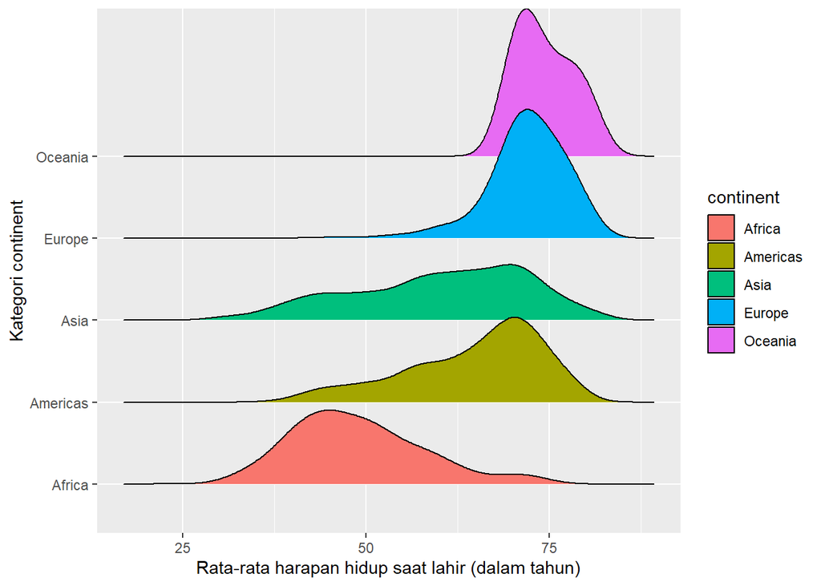

```r
ggplot(data = gapminder, mapping = aes(x = lifeExp, y=continent,fill = continent)) +
  geom_density_ridges() +
  labs(x = "Rata-rata harapan hidup saat lahir (dalam tahun)", y = "Kategori continent")
```

## BOXPLOT

Untuk membuat **boxplot** di ggplot2 kita dapat gunakan function `geom_boxplot()`

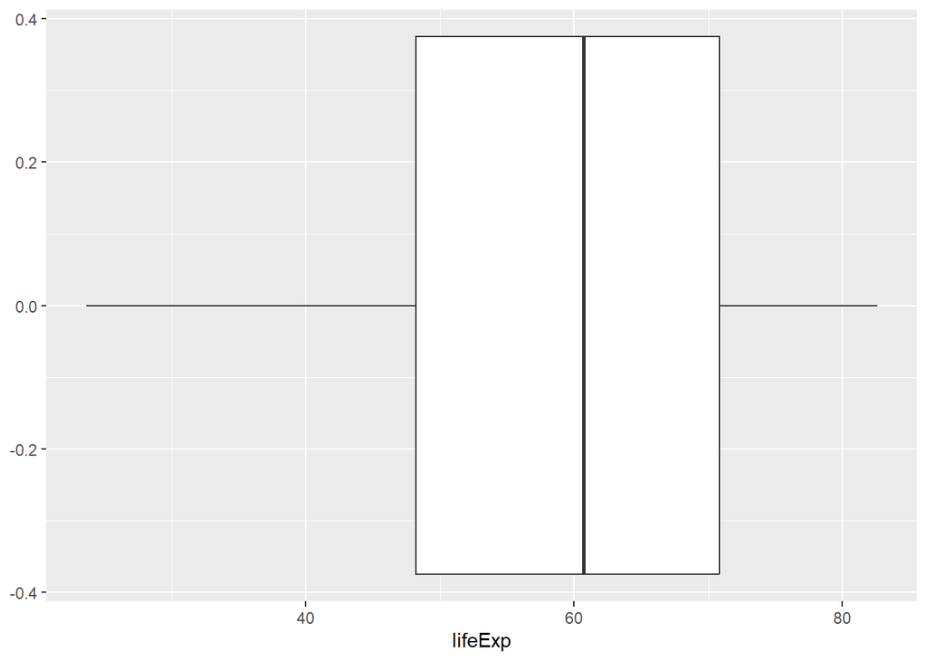

```r
ggplot(data = gapminder, mapping = aes(x = lifeExp)) +
  geom_boxplot()
```

Membuat boxplot secara vertikal menggunakan perintah `coord_flip()`. Hasilnya sebagai berikut.

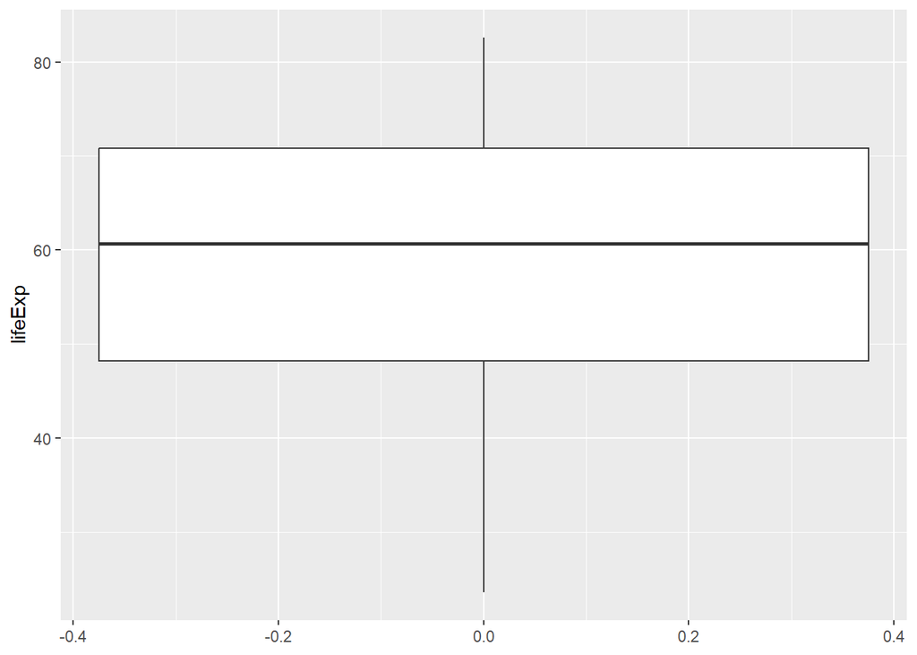

```r
ggplot(data = gapminder, mapping = aes(x = lifeExp)) +
  geom_boxplot()+
  coord_flip()
```

kita dapat membuat boxplot dari data numerik dan membandingkan sebarannya berdasarkan kategori. Misalnya kita ingin membandingkan sebaran rata rata hidup saat lahir berdasarkan kategori kelas continent nya Hasilnya sebagai berikut.

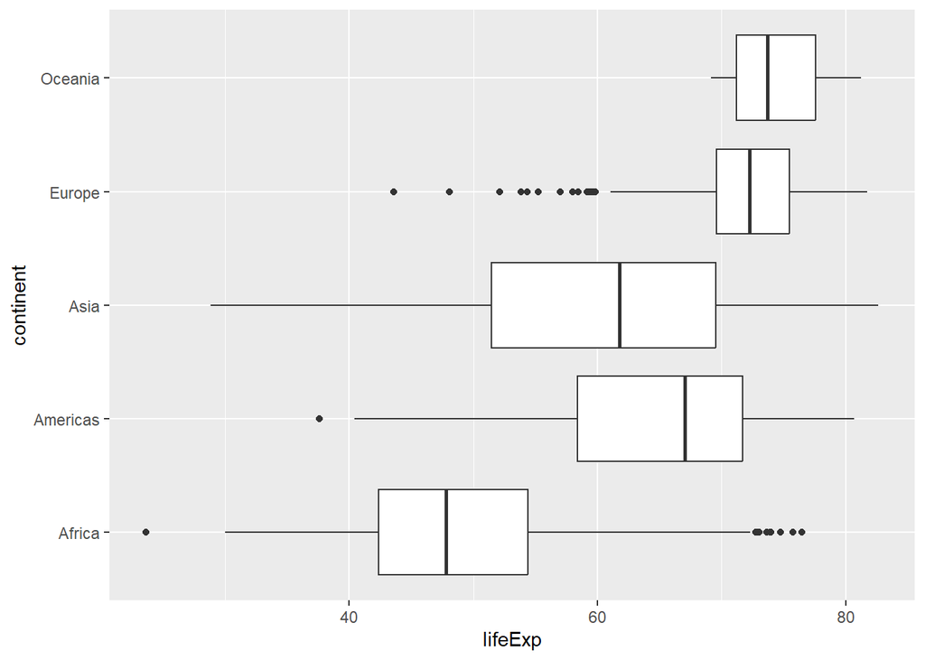

```r
ggplot(data = gapminder, mapping = aes(x = lifeExp, y = continent)) +
  geom_boxplot()
```

semakin panjang maka akan semakin beragam variasinya Selanjutnya memberi warna berbeda untuk setiap box berdasarkan kategorinya. Kita dapat menambahkan argumen `fill` dengan nilai berupa nama variabel dari kategori yang ingin kita gunakan untuk perbandingan boxplot. Misalnya kita ingin membandingkan sebaran dari rata rata hidup saat lahir (lifeExp) berdasarkan kategori continent menggunakan **boxplot** dan menyesuaikan warnanya berdasarkan kategori dari *color*. Hasilnya sebagai berikut.

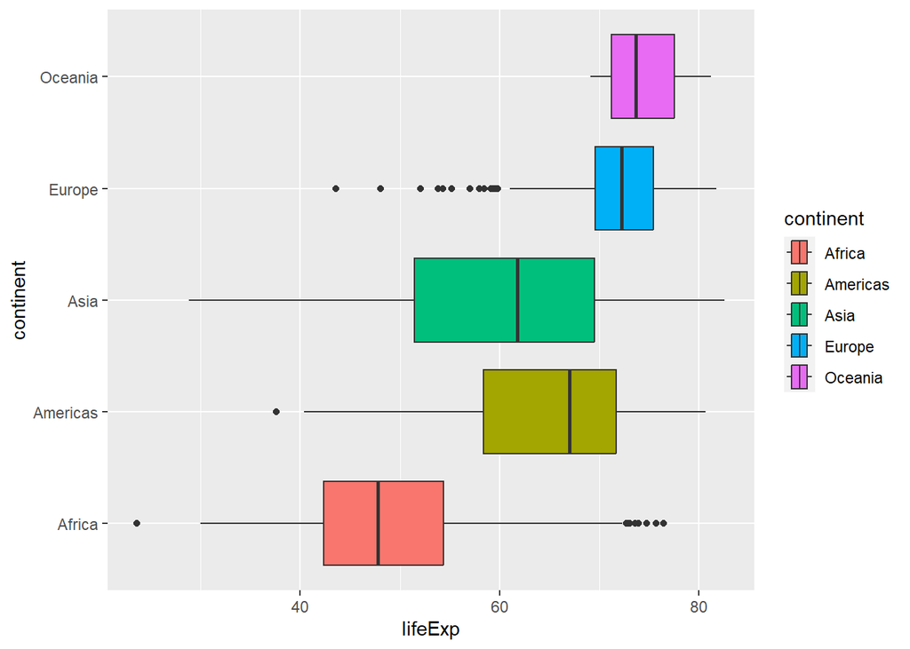

```r
ggplot(data = gapminder, mapping = aes(x = lifeExp, y = continent, fill = continent)) +
  geom_boxplot()
```

Untuk menghilangkan legend dari color kita dapat tambahkan theme(legend.position = “none”).Hasilnya sebagai berikut.

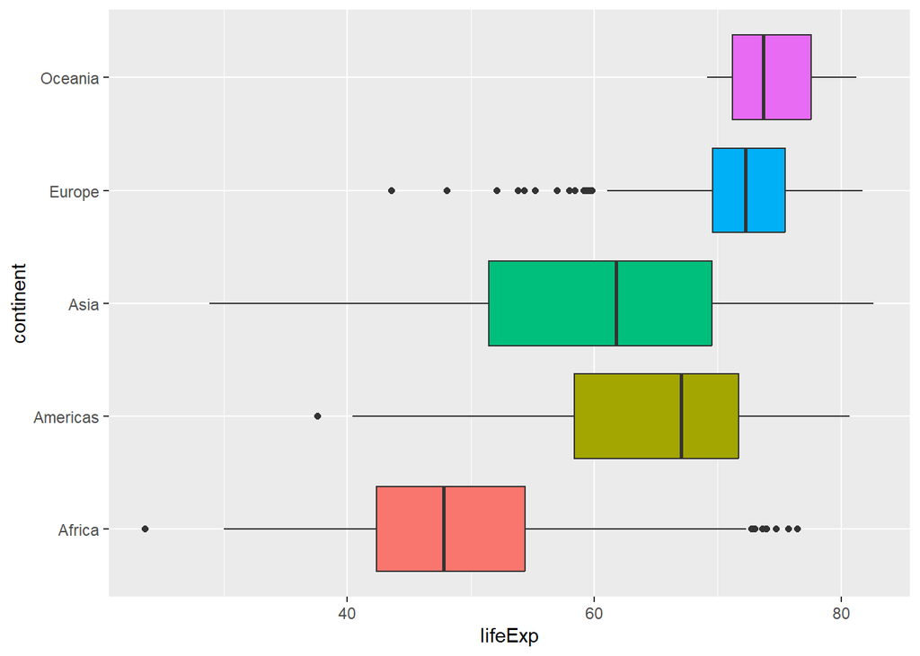

```r
ggplot(data = gapminder, mapping = aes(x = lifeExp, y = continent, fill = continent)) +
  geom_boxplot() +
  theme(legend.position = "none")
```

## VIOLIN PLOT

Plot ini dibentuk dengan menggabungkan antara **Density Plot** dengan **boxplot**. Hasilnya sebagai berikut.

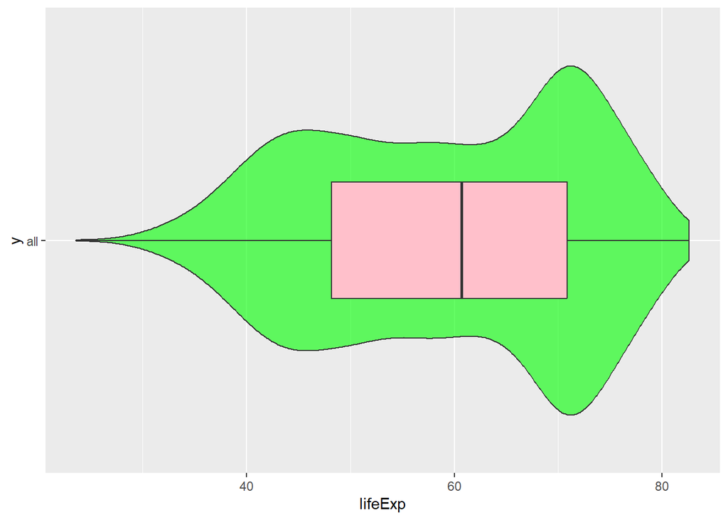

```r
ggplot(data = gapminder, mapping = aes(x = lifeExp ,y="all")) +
  geom_violin(fill="green",alpha=0.6) +
  geom_boxplot(fill="pink",width=0.3)+
   scale_x_continuous(labels = comma)
```

y=all : harus ada y nya

## QQ-PLOT

Plot ini berguna untuk memeriksa apakah sebaran data (sebaran empirik) memiliki bentuk yang sama dengan sebaran tertentu yang dispesifikan (sebaran hipotetik). Misalnya kita ingin melihat pola sebaran rata-rata hidup saat lahir (lifeExp) apakah menyebar normal atau tidak.

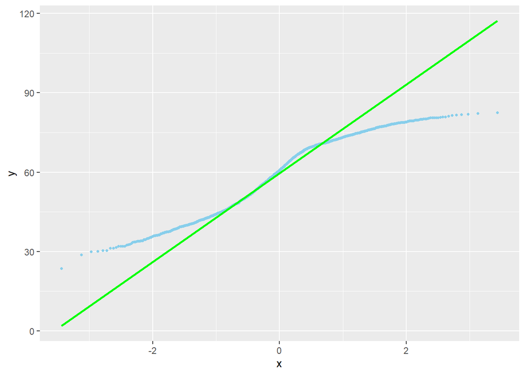

```r
ggplot(data = gapminder, aes(sample = lifeExp)) +
  stat_qq(col="skyblue", cex=0.9) +
  stat_qq_line(col="green", lwd=1)
```

stat_qq_line : apakah menyebar normal atau tidak Jika datanya berhimpit atau mengikuti garis maka akan menyerupai sebaran normal